# CS 422 - HW 10

Mark Gameng, Illinois Institute of Technology

## Part 2.1

### (a)

```r
countries <- read.csv("countries.csv", row.names = 1)
countries
```

|  | GDP | HIV | Lifeexp | Mil | Oilcons | Pop | Tel | Unempl |
| --- | --- | --- | --- | --- | --- | --- | --- | --- |
| Brazil | 8710 | 0.7 | 72.2 | 2.6 | 4.0 | 190 | 204.2 | 9.6 |
| Canada | 35370 | 0.3 | 80.3 | 1.1 | 25.1 | 33 | 622.3 | 6.4 |
| China | 7724 | 0.1 | 72.9 | 4.3 | 1.8 | 1322 | 278.4 | 4.2 |
| France | 29852 | 0.4 | 80.6 | 2.6 | 11.3 | 64 | 543.5 | 8.7 |
| Germany | 31941 | 0.1 | 79.0 | 1.5 | 11.7 | 82 | 657.8 | 7.1 |
| India | 3685 | 0.9 | 68.6 | 2.5 | 0.8 | 1130 | 44.0 | 7.8 |
| Indonesia | 4041 | 0.1 | 70.2 | 3.0 | 1.8 | 235 | 63.2 | 12.5 |
| Italy | 30199 | 0.5 | 79.9 | 1.8 | 11.8 | 58 | 430.8 | 7.0 |
| Japan | 33100 | 0.1 | 82.0 | 0.8 | 16.0 | 127 | 432.8 | 4.1 |
| Mexico | 10570 | 0.3 | 75.6 | 0.5 | 6.6 | 109 | 182.7 | 3.2 |

[output cut: 5 more lines]

### (a.i)

```r
summary(countries)
```

```
      GDP             HIV            Lifeexp           Mil           Oilcons
 Min.   : 3685   Min.   :0.1000   Min.   :65.90   Min.   :0.500   Min.   : 0.80
 1st Qu.: 9640   1st Qu.:0.1000   1st Qu.:72.55   1st Qu.:1.350   1st Qu.: 5.25
 Median :27418   Median :0.3000   Median :78.00   Median :2.500   Median :11.30
 Mean   :22296   Mean   :0.4133   Mean   :76.06   Mean   :2.253   Mean   :10.91
 3rd Qu.:31832   3rd Qu.:0.6500   3rd Qu.:79.85   3rd Qu.:2.700   3rd Qu.:15.10
 Max.   :43369   Max.   :1.1000   Max.   :82.00   Max.   :4.300   Max.   :25.10
      Pop              Tel            Unempl
 Min.   :  33.0   Min.   : 44.0   Min.   : 2.90
 1st Qu.:  59.5   1st Qu.:241.3   1st Qu.: 4.15
 Median : 109.0   Median :432.8   Median : 6.60
 Mean   : 262.8   Mean   :391.3   Mean   : 6.42
 3rd Qu.: 212.5   3rd Qu.:550.4   3rd Qu.: 7.95
 Max.   :1322.0   Max.   :657.8   Max.   :12.50
```

### (a.ii)

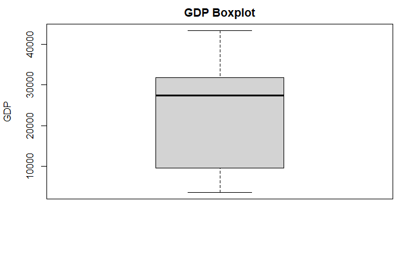

```r
# boxplots
boxplot(countries[,1], ylab = "GDP", main = "GDP Boxplot")
```

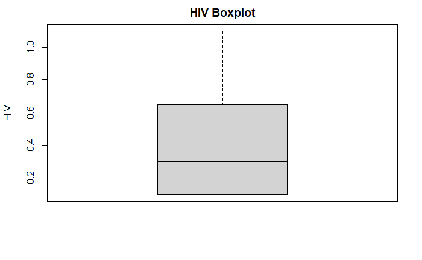

```r
boxplot(countries[,2], ylab = "HIV", main = "HIV Boxplot")
```

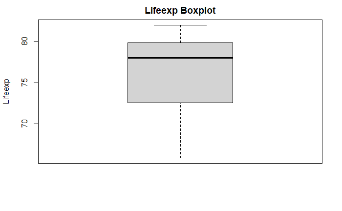

```r
boxplot(countries[,3], ylab = "Lifeexp", main = "Lifeexp Boxplot")
```

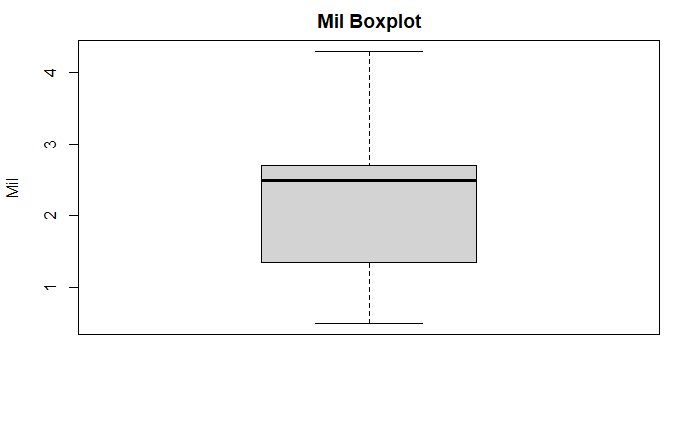

```r
boxplot(countries[,4], ylab = "Mil", main = "Mil Boxplot")
```

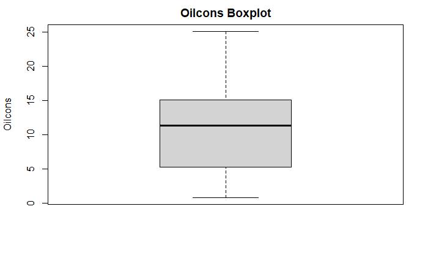

```r
boxplot(countries[,5], ylab = "Oilcons", main = "Oilcons Boxplot")
```

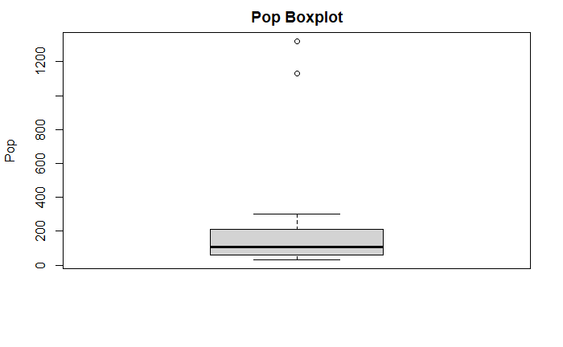

```r
boxplot(countries[,6], ylab = "Pop", main = "Pop Boxplot")
```

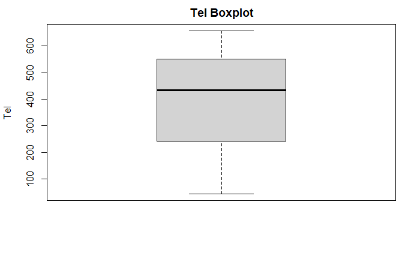

```r
boxplot(countries[,7], ylab = "Tel", main = "Tel Boxplot")
```

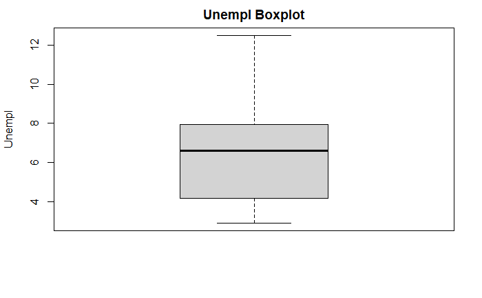

```r
boxplot(countries[,8], ylab = "Unempl", main = "Unempl Boxplot")
```

The two outliers associated with Pop boxplot represents China and India because their population is way above other countries.

### (b)

```r
countries.pca <- prcomp(countries, center = TRUE, scale = TRUE)
```

### (c.i)

```r
summary(countries.pca)
```

```
Importance of components:
                          PC1    PC2    PC3    PC4     PC5     PC6     PC7    PC8
Standard deviation     2.0605 1.1379 1.0170 0.8690 0.59319 0.41733 0.33233 0.1833
Proportion of Variance 0.5307 0.1618 0.1293 0.0944 0.04398 0.02177 0.01381 0.0042
Cumulative Proportion  0.5307 0.6925 0.8218 0.9162 0.96022 0.98199 0.99580 1.0000
```

No components explain at least 90% of the variance. The highest has variance of 0.531.

### (c.ii)

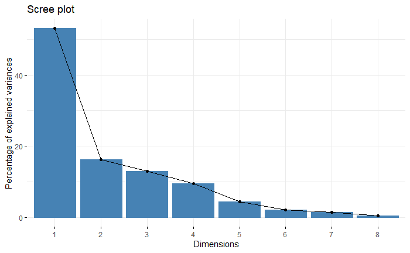

```r
library(factoextra)
fviz_eig(countries.pca)
```

### (c.iii)

Based on the screeplot, I would use 4 or 5 components for modeling if I were to engage in a feature reduction tastk.

### (d)

```r
countries.pca$rotation
```

```
               PC1         PC2          PC3         PC4         PC5         PC6        PC7
GDP      0.4560268  0.06362084 -0.271093835 -0.05442480  0.14947678 -0.08002969  0.1466324
HIV     -0.1934368 -0.32800239 -0.694218852  0.48404674  0.19548002 -0.23804695  0.1456698
Lifeexp  0.4407804  0.01452102  0.187653505 -0.14486052  0.44812657 -0.24828417  0.5683508
Mil     -0.1964834  0.56706336 -0.480082473 -0.41625346 -0.32517176 -0.05002767  0.3340639
Oilcons  0.4275287  0.03644676 -0.320454603  0.04650622  0.07839373  0.78889952 -0.1184137
Pop     -0.3150143  0.54189871  0.006639875  0.07981396  0.72635243  0.05264696 -0.2583224
Tel      0.4423016  0.14093180 -0.200094388 -0.11206139 -0.07267202 -0.49436031 -0.6471483
Unempl  -0.2099599 -0.50174771 -0.190006038 -0.73986102  0.30639110  0.05705115 -0.1520024
                PC8
GDP      0.81319670
HIV     -0.15052276
Lifeexp -0.40474473
Mil     -0.12747214
Oilcons -0.26173851
Pop      0.06006144
Tel     -0.25186858
Unempl   0.02084195
```

### (d.i)

PC1 is positively correlated with GDP, Lifeexp, Oilcons, and Tel. It is negatively correlated with HIV, Mil, Pop, and Unempl. Based on this, my expectation of PC1 is that it is focused on the money side of things because positively correlated to GDP, Oilcons, Tel and Lifeexp which, in general, the more money, the higher the life expectancy. GDP, Lifeexp, Oilcons, and Tel all are high values, being close to 0.45.

### (d.ii)

PC2 is positively correlated with GDP, Lifeexp, Mil, Oilcons, Pop, Tel. It is negatively correlated with HIV, Unempl. Based on this, my expectations of PC2 is that it is similar to PC1 but more general as it correlates more to Mil and Pop. It is also more negatively correlated to HIV and Unempl (-.193 vs -.328 and -.21 vs -.5). Mil and Pop have the most magnitude and is the most relevant, 0.5671 and 0.5419.

### (e)

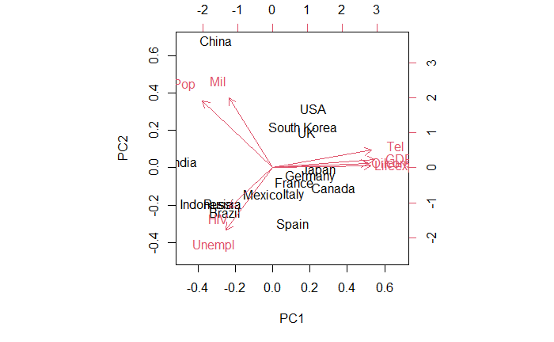

```r
biplot(countries.pca, choices = 1:2)
```

### (e.i)

```r
countries.pca$x[c("Brazil", "UK", "Japan"),1:2]
```

```
             PC1         PC2
Brazil -2.037017 -1.03998472
UK      1.456991  0.83445072
Japan   2.013116 -0.05735491
```

### (e.ii)

Brazil has PC1 = -2.04 and PC2 = -1.04. This makes sense because Brazil has pretty low attributes across the board which resulted in negative values for PC1 and PC2.

Japan has PC1 = 2.01 and PC2 = -0.0574. This makes sense because while Japan has a pretty high GDP, Lifeexp, Oilcons, and Tel, which results in a quite high positive value for PC1, but has a pretty low Mil and Pop which results in a pretty low and negative value for PC2.

UK has PC1 = 1.46 and PC2 = 0.8345. This makes sense because UK has quite high GDP, Lifeexp, Oilcons, and Tel but low Mil and Pop which makes PC2 lower.

## Part 2.2

### User Profiles

```r
library(lsa)
users <- read.csv("ratings.csv")
movies <- read.csv("movies.csv")
my_id <- 20419026 %% 671
profile.dfu <- users[users$userId == my_id,]
#profile.dfu
profile.dfm <- movies[movies$movieId %in% profile.dfu$movieId,]
#profile.dfm
profile.tuser <- data.frame()
names <- c("Action", "Adventure", "Animation",
           "Children", "Comedy", "Crime", "Documentary",
           "Drama", "Fantasy", "Film-Noir", "Horror",
           "IMAX", "Musical", "Mystery", "Romance",
           "Sci-Fi", "Thriller", "War", "Western",
           "(no genres listed)")
for (k in names) profile.tuser[[k]] <- as.numeric()
#profile.dfm
for (name in row.names(profile.dfm)){
  genres <- profile.dfm[name, c("genres")]
  genres <- strsplit(genres, "\\|")
  name <- if (name == "Sci-Fi") "Sci.Fi" else name
  for (genre in genres){
    profile.tuser[as.character(profile.dfm[name, c("movieId")]), as.character(genre)] = 1
  }
}
#profile.tuser
profile.user <- colSums(profile.tuser[,], na.rm = TRUE)
profile.user <- profile.user/nrow(profile.dfm)
profile.user
```

```
            Action          Adventure          Animation           Children
        0.38095238         0.23809524         0.03174603         0.08730159
            Comedy              Crime        Documentary              Drama
        0.28571429         0.14285714         0.00000000         0.46031746
           Fantasy          Film-Noir             Horror               IMAX
        0.07936508         0.00000000         0.04761905         0.02380952
           Musical            Mystery            Romance             Sci-Fi
        0.03174603         0.05555556         0.22222222         0.08730159
          Thriller                War            Western (no genres listed)
        0.38888889         0.03968254         0.04761905         0.00000000
```

### Movie Profiles

```r
profile.dfms <- movies[sample(nrow(movies), 10),]
profile.tdfms <- data.frame()
names <- c("Action", "Adventure", "Animation",
           "Children", "Comedy", "Crime", "Documentary",
           "Drama", "Fantasy", "Film-Noir", "Horror",
           "IMAX", "Musical", "Mystery", "Romance",
           "Sci-Fi", "Thriller", "War", "Western",
           "(no genres listed)")
for (k in names) profile.tdfms[[k]] <- as.numeric()
for (name in row.names(profile.dfms)){
  genres <- profile.dfms[name, c("genres")]
  genres <- strsplit(genres, "\\|")
  #cat(unlist(genres), "\n")
  for (genre in genres){
    profile.tdfms[as.character(profile.dfms[name, c("movieId")]), as.character(genre)] = 1
  }
}
#profile.dfms
profile.tdfms
```

|  | Action | Adventure | Animation | Children | Comedy | Crime | Documentary | Drama | Fantasy | Film-Noir | Horror | IMAX | Musical | Mystery | Romance | Sci-Fi | Thriller | War | Western | (no genres listed) |
| --- | --- | --- | --- | --- | --- | --- | --- | --- | --- | --- | --- | --- | --- | --- | --- | --- | --- | --- | --- | --- |
| 68205 | 1 | NA | NA | NA | 1 | 1 | NA | NA | NA | NA | NA | NA | NA | NA | NA | NA | NA | NA | NA | NA |
| 53519 | 1 | 1 | NA | NA | NA | 1 | NA | NA | NA | NA | 1 | NA | NA | NA | NA | NA | 1 | NA | NA | NA |
| 115147 | NA | NA | NA | NA | NA | NA | NA | 1 | NA | NA | NA | NA | NA | NA | 1 | NA | NA | NA | NA | NA |
| 127198 | NA | NA | NA | NA | 1 | NA | NA | 1 | NA | NA | NA | NA | NA | NA | NA | NA | NA | NA | NA | NA |
| 96530 | NA | NA | NA | NA | 1 | NA | NA | NA | NA | NA | NA | NA | NA | NA | 1 | NA | NA | NA | NA | NA |
| 4803 | NA | NA | NA | NA | NA | NA | NA | 1 | NA | NA | NA | NA | NA | NA | NA | NA | 1 | NA | NA | NA |
| 2100 | NA | NA | NA | NA | 1 | NA | NA | NA | 1 | NA | NA | NA | NA | NA | 1 | NA | NA | NA | NA | NA |
| 7832 | NA | NA | NA | NA | 1 | 1 | NA | NA | NA | NA | NA | NA | NA | 1 | NA | NA | NA | NA | NA | NA |
| 7189 | NA | NA | NA | NA | 1 | NA | NA | NA | NA | NA | NA | NA | NA | NA | NA | NA | NA | NA | NA | NA |
| 8918 | NA | NA | NA | NA | 1 | 1 | NA | 1 | NA | NA | NA | NA | NA | NA | NA | NA | NA | NA | NA | NA |

### Recommendations

```r
profile.tdfms[is.na(profile.tdfms)] <- 0
out.movieId <- c()
out.movieName <- c()
out.similarity <- c()
i <- 1
for (movie in row.names(profile.tdfms)){
  mp <- unlist(profile.tdfms[movie,])
  #typeof(unlist(profile.tdfms[movie,]))
  #cat(unlist(profile.tdfms[movie,]), typeof(unlist(profile.tdfms[movie,])), "\n")
  sim <- lsa::cosine(profile.user, mp)
  out.movieId[i] <- movie
  out.movieName[i] <- movies[movies$movieId == movie, c("title")]
  out.similarity[i] <- sim
  i <- i + 1
}
output <- data.frame(MovieId = out.movieId, MovieName = out.movieName,
                     Similarity = out.similarity)
output <- output[order(output$Similarity, decreasing = TRUE),]
cat("User ID", my_id, "chose the following 10 movies:", row.names(profile.tdfms), "\n")
```

```
User ID 496 chose the following 10 movies: 68205 53519 115147 127198 96530 4803 2100 7832 7189 8918
```

```r
cat("Of these, the following 5 movies are reccomended:", "\n")
```

```
Of these, the following 5 movies are reccomended:
```

```r
head(output, 5)
```

|  | MovieId | MovieName | Similarity |
| --- | --- | --- | --- |
| 6 | 4803 | Play Misty for Me (1971) | 0.6935197 |
| 2 | 53519 | Death Proof (2007) | 0.6189876 |
| 4 | 127198 | Dope (2015) | 0.6092603 |
| 10 | 8918 | Eulogy (2004) | 0.5927171 |
| 3 | 115147 | The Best of Me (2014) | 0.5574084 |